# An overview of relevant NGS reporting elements

Manuela Benary (Charité Comprehensive Cancer Center / Core Unit Bioinformatics (BIH))https://https://www.cubi.bihealth.org/  
2023-03-31

## VICC NGS reporting survey

Results of Next Generation Sequencing (NGS) are increasingly incorporated in routine clinical oncology. Multiple guidelines and standards have been issued globally to support clinical NGS variant interpretation and are currently integrated in different ways into cancer NGS reports around the world. However, a thorough capture of how these guidelines are being translated in real-world laboratory reporting has not yet been clearly studied. To this end, the Variant Interpretation for Cancer Consortium Virtual Molecular Tumor Board (VICC-VMTB), in collaboration with the Cancer Genomics Consortium (CGC) and the ClinGen Somatic Clinical Domain Working Group (CDWG), distributed a comprehensive survey regarding reporting practices for cancer NGS testing worldwide to identify essential elements and their actual occurrence in NGS reports.

## Distributing the survey within DNPM

The survey was distributed among members of the network DNPM in multiple rounds.

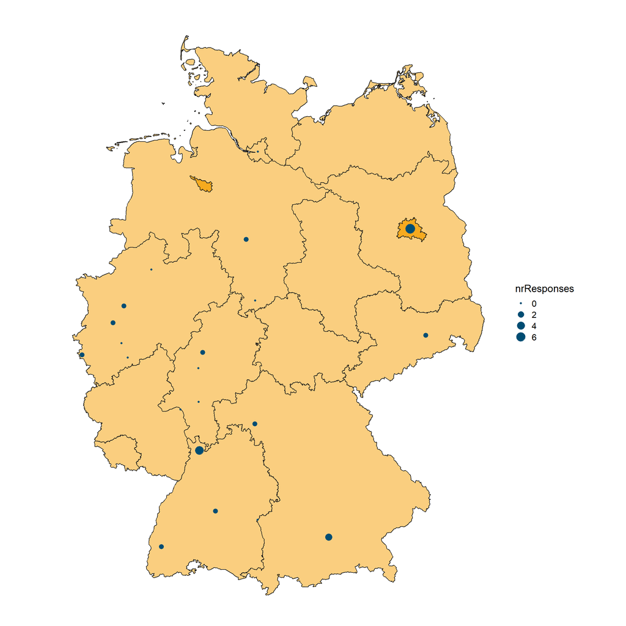

In total, 24 participants from the different members of DNPM answered the survey.

|  | City | Institute | nrResponses |
| --- | --- | --- | --- |
| 1 | Berlin | charite | 7 |
| 2 | Heidelberg | med.uni-heidelberg | 3 |
| 3 | Heidelberg | nct-heidelberg | 2 |
| 4 | München | lmu | 1 |
| 5 | Düsseldorf | med.uni-duesseldorf | 1 |
| 6 | Tübingen | med.uni-tuebingen | 1 |
| 7 | Hannover | mh-hannover | 1 |
| 8 | München | mri.tum | 1 |
| 9 | Marburg | staff.uni-marburg | 1 |
| 10 | München | tum | 1 |

[output cut: 14 more lines]

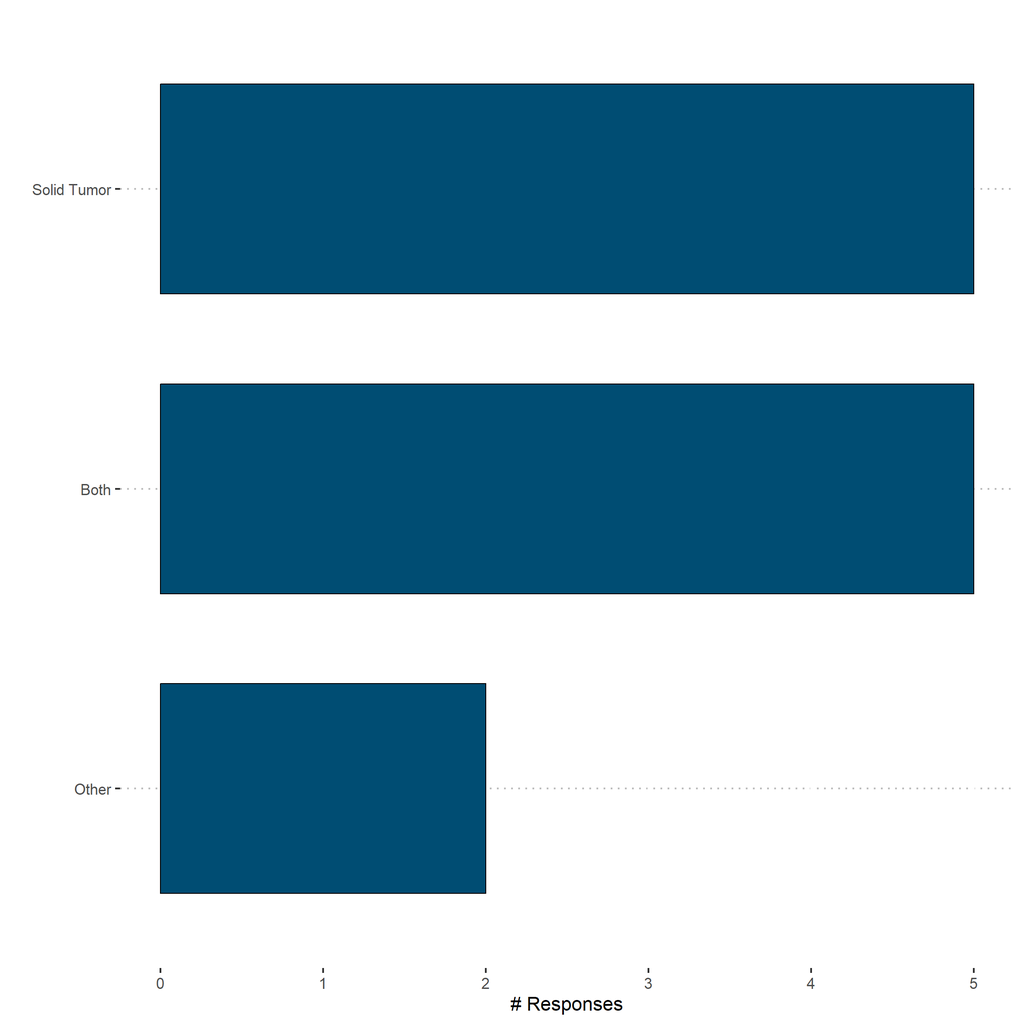

## Defining essential elements for molecular reports

Questions were organized into groups, based on topic of the presented elements. These groups include

- general information,
- variant information with a focus on SNVs and small indels,
- functional annotation,
- clinical information,
- aspects of clinical trials, and
- more complex molecular profiles.

Each element of an NGS report can be defined as a) essential (E), b) preferred, but not essential (P) or c) not recommended (N). The responses are summarized as a score of essentiality (SE), which is normalized between the range of -1 (contra-productive) and 1 (essential):

$$SE = \frac{(E+ 0.5\cdot P − N)}{\text{#responses}}$$

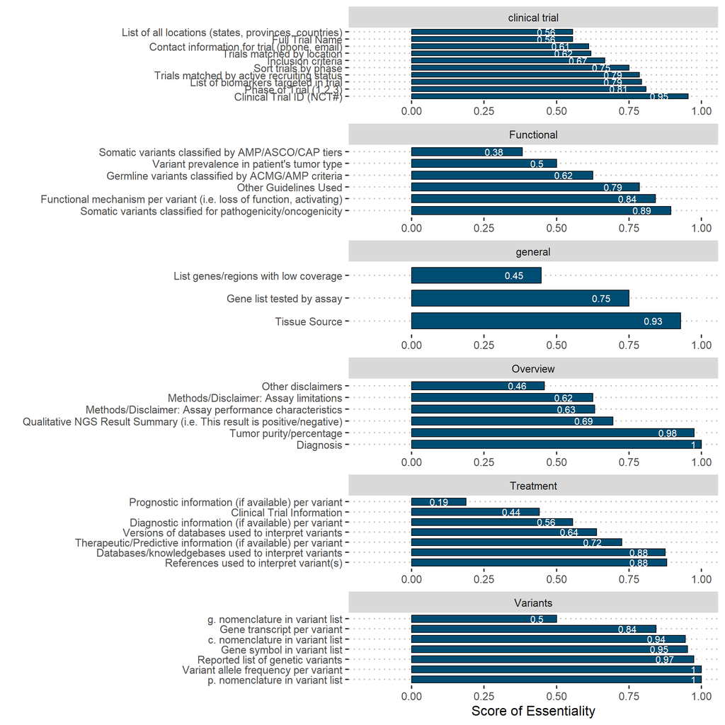

|  | group | name | sum essentiality | # responses | SE |
| --- | --- | --- | --- | --- | --- |
| 1 | clinical trial | Full Trial Name | 10 | 18 | 0.555555555555556 |
| 2 | clinical trial | List of all locations (states, provinces, countries) | 5 | 9 | 0.555555555555556 |
| 3 | clinical trial | Contact information for trial (phone, email) | 5.5 | 9 | 0.611111111111111 |
| 4 | clinical trial | Trials matched by location | 13 | 21 | 0.619047619047619 |
| 5 | clinical trial | Inclusion criteria | 8 | 12 | 0.666666666666667 |
| 6 | clinical trial | Sort trials by phase | 6 | 8 | 0.75 |
| 7 | clinical trial | Trials matched by active recruiting status | 16.5 | 21 | 0.785714285714286 |
| 8 | clinical trial | List of biomarkers targeted in trial | 13.5 | 17 | 0.794117647058823 |
| 9 | clinical trial | Phase of Trial (1,2,3) | 17 | 21 | 0.80952380952381 |
| 10 | clinical trial | Clinical Trial ID (NCT#) | 21 | 22 | 0.954545454545455 |

[output cut: 29 more lines]

## Comparison between reported and essential elements

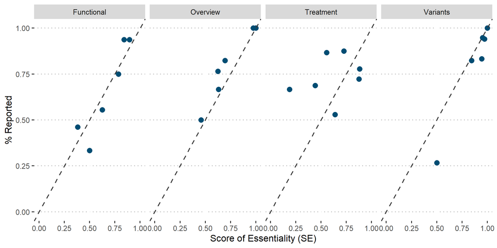

|  | group | name | # responses | % reported | SE |
| --- | --- | --- | --- | --- | --- |
| 1 | Functional | Somatic variants classified by AMP/ASCO/CAP tiers | 13 | 0.461538461538462 | 0.382352941176471 |
| 2 | Functional | Variant prevalence in patient's tumor type | 18 | 0.333333333333333 | 0.5 |
| 3 | Functional | Germline variants classified by ACMG/AMP criteria | 18 | 0.555555555555556 | 0.625 |
| 4 | Functional | Other Guidelines Used | 8 | 0.75 | 0.785714285714286 |
| 5 | Functional | Functional mechanism per variant (i.e. loss of function, activating) | 16 | 0.9375 | 0.842105263157895 |
| 6 | Functional | Somatic variants classified for pathogenicity/oncogenicity | 16 | 0.9375 | 0.894736842105263 |
| 7 | Overview | Other disclaimers | 12 | 0.5 | 0.458333333333333 |
| 8 | Overview | Methods/Disclaimer: Assay limitations | 17 | 0.764705882352941 | 0.625 |
| 9 | Overview | Methods/Disclaimer: Assay performance characteristics | 18 | 0.666666666666667 | 0.631578947368421 |
| 10 | Overview | Qualitative NGS Result Summary (i.e. This result is positive/negative) | 17 | 0.823529411764706 | 0.694444444444444 |

[output cut: 16 more lines]

## Molecular profiles

This includes only the responses and it is normalized to the total number of responses. Therefore it should also reflect, that people were able to choose multiple options.

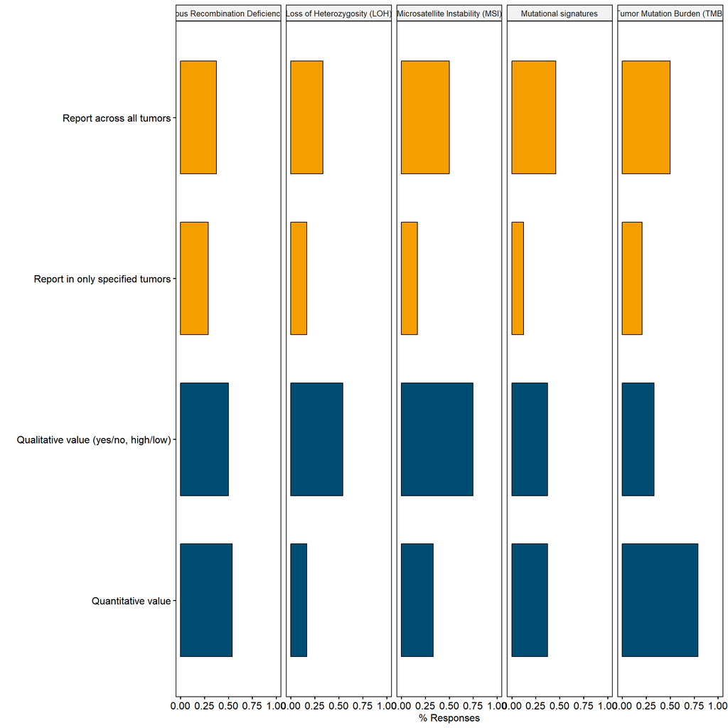

## Additional free text responses

We included the following questions, which allowed for a free form response:

1. Are there other considerations for cancer NGS reports that are not included in this survey?
2. How do you report interacting variants? (i.e. EGFR amplification and EGFR T790M)
3. What information do you include in a cancer genomic NGS disclaimer?
4. Provide any details clarifying answer on previous question on report organization for different variant types.

Answers were given for question # 4 and are provided below:

|  | value |
| --- | --- |
| 1 | clear - comprehensive -&gt; usage of tables and final statement (text) |
| 2 | Better overview in different tables. Also different parameters to be reported. |
| 3 | Concluding remarks summarizing all positive biomarkers |
| 4 | Separate reports per assay allow a clearer and not mixed presentation of results depending on assay or starting material. Furthermore, each assay has its own QC parameter and assay dependent analysis … |
| 5 | Separate |
| 6 | but we would mention correlations in the interpretation |
| 7 | Due to the different clincial implications of different alterations (MET amplification, MET exon 14 skipping), these and the respective pathogenicity should be reported separately. |
| 8 | results are dependend on methods, and the report is structured accordingly |